# clustering

We will explore a dataset of user knowledge data, from the paper:

```
H. T. Kahraman, Sagiroglu, S., Colak, I., Developing intuitive knowledge classifier and modeling of users' domain dependent data in web,
Knowledge Based Systems, vol. 37, pp. 283-295, 2013.
```

I wasn't able to access a copy of the paper itself, so I don't know exactly how the data was used. Regardless, it should suffice for demonstrating the process of data mining using K-means clustering.

```r
library(dplyr)
library(cluster)
library(ggplot2)
library(tidyr)
library(scatterplot3d)
library(plotly)
```

```r
user_data <- as.data.frame(read.csv("user_modelling.csv"))
```

The source data contains 5 independent variables (each a decimal value from 0 to 1) and one dependent variable (categorical: one of Very Low, Low, Medium, or High).

The first variable, STG, represents the amount of study time for the specific goal.

SCG is the degree of repetition of the goal object.

STR is the amount of study time for related materials.

LPR is the exam performance for related materials.

PEG is the exam performance for the specific goal.

UNS - the dependent variable - represents the knowledge value of the user.

For our purposes we will limit our analysis to 3 independent variables. This will allow us to visualise the output, at the cost of less accuracy. We will discard STR and LPR as they measure performance of related tasks, whereas the other variables measure performance of goal-specific tasks.

```r
cleaned_data <- user_data[,c(1, 2, 5)]
```

Let's rename those variables for clarity:

```r
colnames(cleaned_data) <- c("Study_Time", "Repetition", "Exam_Performance")
head(cleaned_data)
```

| Study_Time | Repetition | Exam_Performance |
| --- | --- | --- |
| 0.00 | 0.00 | 0.00 |
| 0.08 | 0.08 | 0.90 |
| 0.06 | 0.06 | 0.33 |
| 0.10 | 0.10 | 0.30 |
| 0.08 | 0.08 | 0.24 |
| 0.09 | 0.15 | 0.66 |

And convert the data frame to a matrix:

```r
user_matrix <- as.matrix(cleaned_data)
```

Now, we plan to apply a K-Means clustering to the data so the next step is to select a value for K. To do this, we will calculate the Within Sum of Squares value for each possible K, from 1 to 12.

```r
n <- 12
wss <- numeric(n)

for (k in 1:n) {
    wss[k] <- sum(kmeans(user_matrix, centers=k, nstart=25)$withinss)
}
```

Plotting the values of wss we just created, we can select an appropriate value for K.

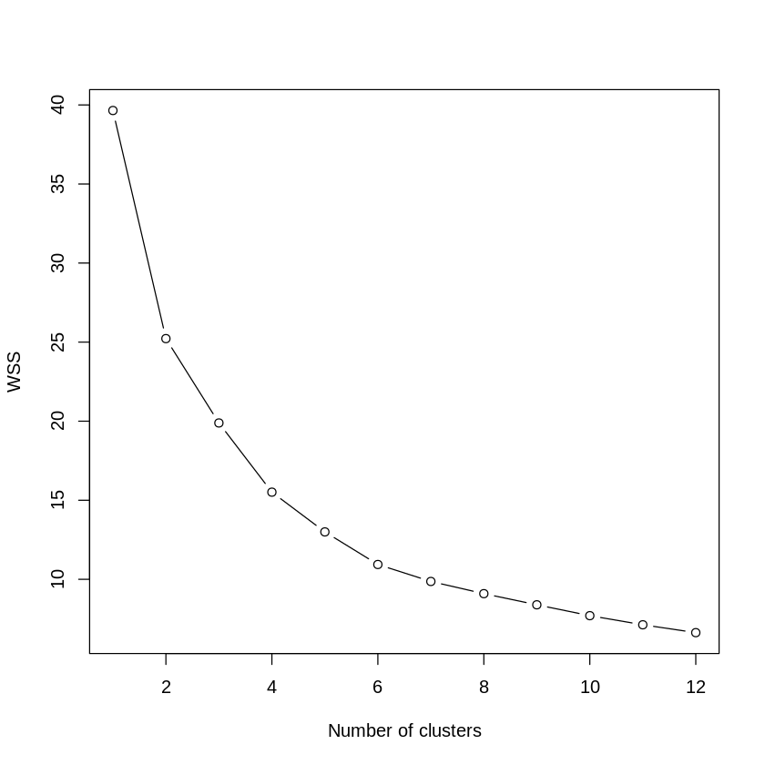

```r
plot(1:12, wss, type="b", xlab="Number of clusters", ylab="WSS")
```

It seems K = 4 to K = 7 would be reasonable. We will choose K = 4 to avoid overfitting (where the clustering is too fine), and because it simplifies our output.

With this specific dataset we also know that our dependent variable is a categorical factor with 4 levels so K = 4 is the obvious choice. In a real world setting of course that knowledge would not be available to us.

Now we can tell R to perform the clustering:

```r
(km <- kmeans(user_matrix, 4, nstart=25))
```

```
K-means clustering with 4 clusters of sizes 48, 76, 100, 34

Cluster means:
  Study_Time Repetition Exam_Performance
1  0.3643958  0.6972917        0.4944375
2  0.2944211  0.2799079        0.6913158
3  0.3055900  0.2534100        0.2077000
4  0.7450000  0.3435294        0.6252941

Clustering vector:
  [1] 3 2 3 3 3 2 2 3 3 2 2 3 3 2 2 2 3 3 3 2 3 2 2 3 3 2 3 3 2 2 2 3 3 2 2 3 3
 [38] 3 3 2 3 2 2 3 3 2 2 2 2 2 3 1 3 1 1 1 3 1 2 3 3 1 1 1 1 3 3 2 3 2 2 2 3 2
 [75] 2 3 3 3 3 3 3 2 2 3 3 3 2 3 3 2 2 3 3 3 2 3 3 2 2 3 3 2 2 3 3 2 2 2 3 2 3
[112] 3 2 2 1 1 3 1 1 1 1 1 1 1 1 1 1 1 1 1 3 2 3 2 2 2 3 3 2 3 3 3 2 3 2 2 3 3
[149] 3 2 2 3 3 3 2 2 2 2 2 2 3 3 2 2 3 2 2 2 3 2 3 2 2 3 2 3 3 2 1 2 1 1 1 1 1
[186] 1 1 1 1 1 1 1 1 1 4 3 3 4 4 3 3 4 3 3 4 3 4 4 3 4 4 4 4 4 4 3 3 4 2 3 3 4
[223] 4 4 3 4 4 3 4 4 4 3 3 4 4 3 3 4 4 4 3 4 4 1 1 4 1 1 4 4 4 1 3 1 4 1 1 1

Within cluster sum of squares by cluster:
[1] 3.842299 3.758363 5.871801 2.038502
 (between_SS / total_SS =  60.9 %)

Available components:

[1] "cluster"      "centers"      "totss"        "withinss"     "tot.withinss"
[6] "betweenss"    "size"         "iter"         "ifault"
```

And transfer the results back into a data frame so as to more easily visualise them:

```r
results <- as.data.frame(user_matrix)
results$cluster <- factor(km$cluster)
centers <- as.data.frame(km$centers)
```

Visualising 3-dimensional data in a 2-dimensional medium can be challenging. The scatterplot3d function attempts it, with *some* success

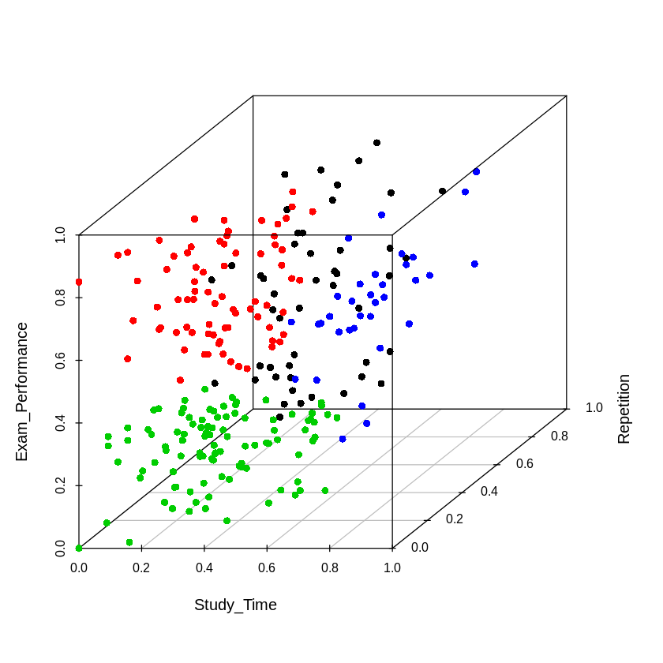

```r
scatterplot3d(results, pch=16, color=results$cluster)
```

Assuming the reader is using an interactive environment, we can use a service like plotly to generate 3-dimensional visualisations:

```r
ply <- plot_ly(results, x=~Study_Time, y=~Repetition, z=~Exam_Performance, marker=list(color=~cluster, colorscale="Rainbow", showscale=FALSE)) %>%
  add_markers() %>%
  layout(scene=list(xaxis=list(title="Study_Time"),
                    yaxis=list(title="Repetition"),
                    zaxis=list(title="Exam_Performance")))
```

```r
api_create(ply, filename="clustering_user_modelling")
# creates https://plot.ly/~davidpayne/1/#/
```

[interactive chart not shown]

```
Found a grid already named: 'clustering_user_modelling Grid'. Since fileopt='overwrite', I'll try to update it
Found a plot already named: 'clustering_user_modelling'. Since fileopt='overwrite', I'll try to update it
```

```r
head(results)
```

| Study_Time | Repetition | Exam_Performance | cluster |
| --- | --- | --- | --- |
| 0.00 | 0.00 | 0.00 | 3 |
| 0.08 | 0.08 | 0.90 | 2 |
| 0.06 | 0.06 | 0.33 | 3 |
| 0.10 | 0.10 | 0.30 | 3 |
| 0.08 | 0.08 | 0.24 | 3 |
| 0.09 | 0.15 | 0.66 | 2 |

Depending on the question to be answered, this may be the end of the analysis. In data mining, identifying clusters may be sufficient. In a complete data analysis process there are likely to be additional steps, such as checking the results against those returned by other algorithms, or using the clusters identified as the basis for further exploration.